# Replication of Study 2 by Walsh & Sloman (2004)

Erin Bennett `erindb@stanford.edu`

# Introduction

This study is about how people revise their beliefs when they are presented with a counterexample to a causal relationship.

This research addresses a few questions:

1. **Are other effects screened off from the effect in the counterexample, given that the cause happened?** That is, do people update their beliefs about that particular causal relationship in isolation, without influencing other parts of their theory? Or do they update their theory in a more complex way such that in this and other counterexamples, other things that usually result from the cause are also less likely? E.g. “My new neighbors tell me they are in a fraternity. I think they will have loud parties late at night and their apartment will be messy. If after a few weekends, the apartment is always really quiet, my expectation might be less strong that it’s messy.”

   Walsh & Sloman found that effects are not screened off and that the counterexample results in people expecting other possible consequents less.

   The main comparison that I will consider a replication is Comparison 1.

   *Comparison 1:* For “A causes B” and “A causes C”, ask participants about two situations:
   1. A is true. How likely is C? (baseline)
   2. A is true and B is false. How likely is C? (counterexample)

   If B and C are screened off from one another given A, then both questions should have the same answer. If participants are revising their theories in a more comples way, they might be different. In fact, the answer for 2 tends to be lower than the answer for 1.
2. **Do people revise their causal believes in the face of a counterexamples?** That is, are these exceptions, conditions, etc. already known and accounted for and participants just have enough evidence for them when they see the counterexample? Or are they adding them in as needed? E.g. “If a *new fraternity* replaces my neighbors that may or may not be nerdy (I just don’t know), then will my experience with my quiet neighbors influence my expectations about the new fraternity?”

   Walsh & Sloman found that people have report different probabilities of effects given causes for (almost) the same question after the counterexample.

   *Comparison 2:* Ask participants about P(C|A) before and after the counterexample.
   1. A is true. How likely is C? (baseline)
   2. A is true and you don’t know whether that explanation you gave for the counterexample situation is true. How likely is C? (generalization)

   If beliefs are not revised, you would expect no difference between these responses, because 2 has no more information than 1 (literally, at least). But in fact, responses to these questions tend to be different.

# Methods

The replication experiment can be found at this link: http://erindb.me/254/main-project/.

## Power analysis

Original N=20. Planned N=20.

Effect size for the first comparison – P(B|A) versus P(B|A and not C) – was 1.12, so with the same sample size the power will be d=0.999 (Cohen’s d).

Effect size for the second comparison – P(B|A) versus P(B|A and explanation unknown) – was 1.20, so with the same sample size the power will be 0.999 (Cohen’s d).

I will run an additional 5% (1 participant) so that I can exclude answers to question 3 (generalization) in which participants rated the question as strangely worded.

## Planned sample

English-speaking participants on Amazon’s Mechanical Turk.

## Materials

Walsh & Sloman (2004) report using 6 different stories. Two are used as examples in their 2004 paper.

Stories:

- Jogging regularly causes a person to lose weight. Jogging regularly causes a person to increase their fitness level.
- Worrying causes difficulty in concentrating. Worrying causes insomnia.

These stories were designed such that the effects would not directly affect one another. I created seven more items with this intended causal structure.

- Drinking coffee causes a person to stay up late. Drinking coffee causes a person to be more focused.
- Going to the beach on a sunny day causes a person to get a suntan. Going to the beach on a sunny day causes a person to see surfers.
- Reading for a very long stretch of time causes a person to get a headache. Reading for a very long stretch of time causes a person’s vocabulary to increase.
- Joining a cooking meetup group causes a person to make friends. Joining a cooking meetup group causes a person to get better at cooking.
- Taking a painting class causes a person to get paint on their clothes. Taking a painting class causes a person to improve their painting skills.
- Practicing guitar a lot causes a person to start writing their own songs. Practicing guitar a lot causes a person’s fingers to get calloused.
- Flying from the US to Japan causes a person to experience jetlag. Flying from the US to Japan causes a person to hear more Japanese.

## Procedure

Each participant sees each story. Stories are presented one at a time, in blocks.

In each block, first the causal statements in question are presented. These will be visible for rest of the block. Then the following questions are asked (in order):

1. A is true. How likely is C? (baseline)
2. A is true and B is false.
   1. Why do you think that is? (counterexample)
   2. Also, how likely is C?
3. A is true and you don’t know whether *[the explanation you gave for 2a]* is true. How likely is C? (generalization)
4. A is true and *[the explanation you gave for 2a]* is false. How likely is C? (explanation absent)
5. A is true and *[the explanation you gave for 2a]* is true. How likely is C? (explanation present)

## Analysis plan

Run t-tests to see whether the following replicate:

- *Comparison 1:* $Answer2b < Answer1$
- *Comparison 2:* $Answer1 \neq Answer3$

## Differences from original study

The sample population of the original study was a group of college students. My sample will be participants on Amazon’s Mechanical Turk. Both groups probably reason similarly about causes. However, it is possible that workers on Mechanical Turk will be more concerned about giving consistent answers than college students, so for similarly phrased answers we might expect a slight bias for this new population giving the same answer.

The setting will be online rather than in a lab, which means that participants might be paying less attention, or take breaks in the middle of the study. I don’t anticipate that having a strong effect on the results, since these questions don’t seem to require a lot of concentration.

I will use some basic natural language processing to repeat back participants’ explanations with (hopefully) appropriate syntax. The original study used a human to do this task. Because doing this with a computer is more error-prone, I will have to ask the question in a slightly different way, giving participants a particular syntactic frame to fill in. The resulting program might respond to people with nonsense. Therefore, I also provide a checkbox for participants to mark if they “notice something strange about the way this question is worded”.

# Methods Addendum

## Differences from pre-date collection methods plan

# Results

## Data preparation

I will exclude from analysis answers where participants marked that trial as strangely worded. This will not affect question 1 (baseline) or quesiton 2 (counterexample), since those questions do not echo back participants explanations. This will, however, affect question 3 (generalization).

```r
all.data = d
for (i in 1:nrow(ungrammatical)) {
  exclude.qnum = ungrammatical[i, 'qnum']
  exclude.story = ungrammatical[i, 'story']
  exclude.workerid = ungrammatical[i, 'workerid']
  d = d %>% filter(!(
    workerid==exclude.workerid &
      qnum==exclude.qnum &
      story==exclude.story))
}
stopifnot(nrow(all.data) - nrow(ungrammatical)*2 == nrow(d))
```

## Confirmatory analysis

```r
cond.probs = probs %>% group_by(question, workerid) %>%
  summarise(probability = mean(probability, na.rm=T)) %>%
  as.data.frame %>%
  spread(question, probability)

comp1 = with(cond.probs, t.test(baseline, counterexample, paired=T))
comp2 = with(cond.probs, t.test(baseline, generalization, paired=T))
comp3 = with(cond.probs, t.test(baseline, `explanation absent`, paired=T))
comp4 = with(cond.probs, t.test(counterexample, `explanation present`, paired=T))
replication.n = length(unique(d$workerid))
```

The main comparison that I will consider a replication is Comparison 1.

We ran a paired t-test on the comparison between a participant’s average responses to question 1 (baseline) and question 2b (counterexample). We find evidence that people revise their causal beliefs about other aspects of a particular situation (t(20)=3.69, p=0.0015).

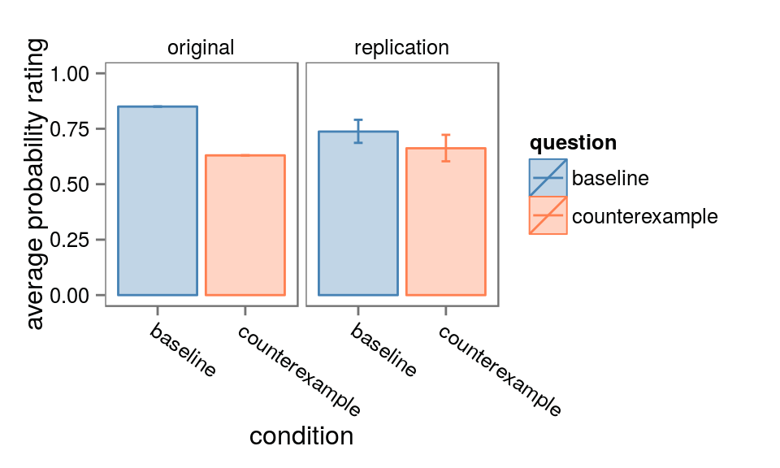

A secondary comparison is the comparison between question 1 (baseline) and question 3 (generalization).

We again ran a paired t-test and find evidence that these participants generalize this revision to other situations (t(20)=4.53, p=210^{-4}).

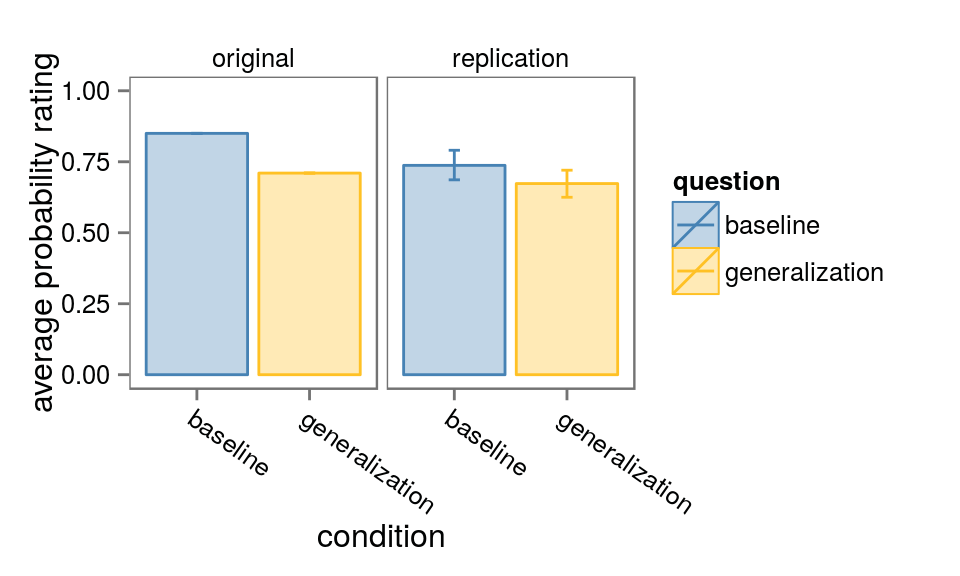

Because the specific scenarios might matter to participants’ responses, we will also run a mixed effects linear regression with random slopes for scenario and participant.

We find a significant effect of question for comparison 1, b=-0.08, t(13.43)=-3.02, p=0.0095.

We find a significant effect of question for comparison 2, b=-0.07, t(24.95)=-3.84, p=710^{-4}.

# Discussion

## Summary of replication attempt

Overall, it seems like the main effects that we sought to replicate from Walsh and Sloman’s study hold in this replication, despite there being several changes in our sample population and methodology.